# Risk Factor Analysis

## Outcome Variable

**Outcome Variable:** stunted

## Predictor Variables

**Intervention Variable:** single

**Adjustment Set:**

- arm
- W_mage
- meducyrs
- feducyrs
- W_mhtcm
- W_mwtkg
- W_mbmi
- delta_W_mage
- delta_meducyrs
- delta_feducyrs
- delta_W_mhtcm
- delta_W_mwtkg
- delta_W_mbmi

## Stratifying Variables

The analysis was stratified on these variable(s):

- agecat
- studyid
- country

## Data Summary

| agecat | studyid | country | single | stunted | n_cell | n |
| --- | --- | --- | --- | --- | --- | --- |
| Birth | COHORTS | GUATEMALA | 0 | 0 | 679 | 767 |
| Birth | COHORTS | GUATEMALA | 0 | 1 | 40 | 767 |
| Birth | COHORTS | GUATEMALA | 1 | 0 | 43 | 767 |
| Birth | COHORTS | GUATEMALA | 1 | 1 | 5 | 767 |
| Birth | COHORTS | INDIA | 0 | 0 | 4206 | 4778 |
| Birth | COHORTS | INDIA | 0 | 1 | 565 | 4778 |
| Birth | COHORTS | INDIA | 1 | 0 | 7 | 4778 |
| Birth | COHORTS | INDIA | 1 | 1 | 0 | 4778 |
| Birth | COHORTS | PHILIPPINES | 0 | 0 | 2760 | 3010 |
| Birth | COHORTS | PHILIPPINES | 0 | 1 | 176 | 3010 |
| Birth | COHORTS | PHILIPPINES | 1 | 0 | 68 | 3010 |
| Birth | COHORTS | PHILIPPINES | 1 | 1 | 6 | 3010 |
| Birth | JiVitA-4 | BANGLADESH | 0 | 0 | 1959 | 2819 |
| Birth | JiVitA-4 | BANGLADESH | 0 | 1 | 855 | 2819 |
| Birth | JiVitA-4 | BANGLADESH | 1 | 0 | 4 | 2819 |
| Birth | JiVitA-4 | BANGLADESH | 1 | 1 | 1 | 2819 |
| Birth | MAL-ED | BANGLADESH | 0 | 0 | 187 | 231 |
| Birth | MAL-ED | BANGLADESH | 0 | 1 | 44 | 231 |
| Birth | MAL-ED | BANGLADESH | 1 | 0 | 0 | 231 |
| Birth | MAL-ED | BANGLADESH | 1 | 1 | 0 | 231 |
| Birth | MAL-ED | BRAZIL | 0 | 0 | 51 | 65 |
| Birth | MAL-ED | BRAZIL | 0 | 1 | 6 | 65 |
| Birth | MAL-ED | BRAZIL | 1 | 0 | 5 | 65 |
| Birth | MAL-ED | BRAZIL | 1 | 1 | 3 | 65 |
| Birth | MAL-ED | INDIA | 0 | 0 | 37 | 47 |
| Birth | MAL-ED | INDIA | 0 | 1 | 10 | 47 |
| Birth | MAL-ED | INDIA | 1 | 0 | 0 | 47 |
| Birth | MAL-ED | INDIA | 1 | 1 | 0 | 47 |
| Birth | MAL-ED | NEPAL | 0 | 0 | 25 | 27 |
| Birth | MAL-ED | NEPAL | 0 | 1 | 2 | 27 |

[output cut: 138 more lines]

The following strata were considered:

- agecat: 24 months, studyid: COHORTS, country: GUATEMALA
- agecat: 24 months, studyid: COHORTS, country: INDIA
- agecat: 24 months, studyid: COHORTS, country: PHILIPPINES
- agecat: 24 months, studyid: JiVitA-4, country: BANGLADESH
- agecat: 24 months, studyid: MAL-ED, country: BANGLADESH
- agecat: 24 months, studyid: MAL-ED, country: BRAZIL
- agecat: 24 months, studyid: MAL-ED, country: INDIA
- agecat: 24 months, studyid: MAL-ED, country: NEPAL
- agecat: 24 months, studyid: MAL-ED, country: PERU
- agecat: 24 months, studyid: MAL-ED, country: SOUTH AFRICA
- agecat: 24 months, studyid: MAL-ED, country: TANZANIA, UNITED REPUBLIC OF
- agecat: 24 months, studyid: PROBIT, country: BELARUS
- agecat: 24 months, studyid: TanzaniaChild2, country: TANZANIA, UNITED REPUBLIC OF
- agecat: 24 months, studyid: ZVITAMBO, country: ZIMBABWE
- agecat: 6 months, studyid: COHORTS, country: GUATEMALA
- agecat: 6 months, studyid: COHORTS, country: INDIA
- agecat: 6 months, studyid: COHORTS, country: PHILIPPINES
- agecat: 6 months, studyid: Guatemala BSC, country: GUATEMALA
- agecat: 6 months, studyid: JiVitA-4, country: BANGLADESH
- agecat: 6 months, studyid: MAL-ED, country: BANGLADESH
- agecat: 6 months, studyid: MAL-ED, country: BRAZIL
- agecat: 6 months, studyid: MAL-ED, country: INDIA
- agecat: 6 months, studyid: MAL-ED, country: NEPAL
- agecat: 6 months, studyid: MAL-ED, country: PERU
- agecat: 6 months, studyid: MAL-ED, country: SOUTH AFRICA
- agecat: 6 months, studyid: MAL-ED, country: TANZANIA, UNITED REPUBLIC OF
- agecat: 6 months, studyid: PROBIT, country: BELARUS
- agecat: 6 months, studyid: TanzaniaChild2, country: TANZANIA, UNITED REPUBLIC OF
- agecat: 6 months, studyid: ZVITAMBO, country: ZIMBABWE
- agecat: Birth, studyid: COHORTS, country: GUATEMALA
- agecat: Birth, studyid: COHORTS, country: INDIA
- agecat: Birth, studyid: COHORTS, country: PHILIPPINES
- agecat: Birth, studyid: JiVitA-4, country: BANGLADESH
- agecat: Birth, studyid: MAL-ED, country: BANGLADESH
- agecat: Birth, studyid: MAL-ED, country: BRAZIL
- agecat: Birth, studyid: MAL-ED, country: INDIA
- agecat: Birth, studyid: MAL-ED, country: NEPAL
- agecat: Birth, studyid: MAL-ED, country: PERU
- agecat: Birth, studyid: MAL-ED, country: SOUTH AFRICA
- agecat: Birth, studyid: MAL-ED, country: TANZANIA, UNITED REPUBLIC OF
- agecat: Birth, studyid: PROBIT, country: BELARUS
- agecat: Birth, studyid: ZVITAMBO, country: ZIMBABWE

### Dropped Strata

Some strata were dropped due to rare outcomes:

- agecat: Birth, studyid: COHORTS, country: INDIA
- agecat: Birth, studyid: JiVitA-4, country: BANGLADESH
- agecat: Birth, studyid: MAL-ED, country: BANGLADESH
- agecat: Birth, studyid: MAL-ED, country: BRAZIL
- agecat: Birth, studyid: MAL-ED, country: INDIA
- agecat: Birth, studyid: MAL-ED, country: NEPAL
- agecat: Birth, studyid: MAL-ED, country: PERU
- agecat: Birth, studyid: MAL-ED, country: SOUTH AFRICA
- agecat: Birth, studyid: MAL-ED, country: TANZANIA, UNITED REPUBLIC OF
- agecat: Birth, studyid: PROBIT, country: BELARUS
- agecat: 6 months, studyid: COHORTS, country: INDIA
- agecat: 6 months, studyid: JiVitA-4, country: BANGLADESH
- agecat: 6 months, studyid: MAL-ED, country: BANGLADESH
- agecat: 6 months, studyid: MAL-ED, country: BRAZIL
- agecat: 6 months, studyid: MAL-ED, country: INDIA
- agecat: 6 months, studyid: MAL-ED, country: NEPAL
- agecat: 6 months, studyid: MAL-ED, country: TANZANIA, UNITED REPUBLIC OF
- agecat: 24 months, studyid: COHORTS, country: INDIA
- agecat: 24 months, studyid: JiVitA-4, country: BANGLADESH
- agecat: 24 months, studyid: MAL-ED, country: BANGLADESH
- agecat: 24 months, studyid: MAL-ED, country: BRAZIL
- agecat: 24 months, studyid: MAL-ED, country: INDIA
- agecat: 24 months, studyid: MAL-ED, country: NEPAL
- agecat: 24 months, studyid: MAL-ED, country: TANZANIA, UNITED REPUBLIC OF
- agecat: 24 months, studyid: TanzaniaChild2, country: TANZANIA, UNITED REPUBLIC OF

## Methods Detail

We’re interested in the causal parameters $E[Y_a]$ for all values of $a \in \mathcal{A}$. These parameters represent the mean outcome if, possibly contrary to fact, we intervened to set all units to have $A=a$. Under the randomization and positivity assumptions, these are identified by the statistical parameters $\psi_a=E_W[E_{Y|A,W}(Y|A=a,W)]$. In addition, we’re interested in the mean of $Y$, $E[Y]$ under no intervention (the observed mean). We will estimate these parameters by using SuperLearner to fit the relevant likelihood factors – $E_{Y|A,W}(Y|A=a,W)$ and $p(A=a|W)$, and then updating our likelihood fit using a joint TMLE.

For unadjusted analyses ($W=\{\}$), initial likelihoods were estimated using Lrnr_glm to estimate the simple $E(Y|A)$ and Lrnr_mean to estimate $p(A)$. For adjusted analyses, a small library containing Lrnr_glmnet, Lrnr_xgboost, and Lrnr_mean was used.

Having estimated these parameters, we will then use the delta method to estimate relative risks and attributable risks relative to a prespecified baseline level of $A$.

# Results Detail

## Results Plots

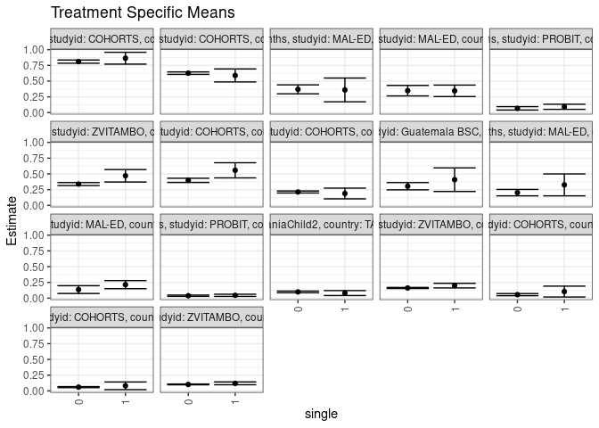

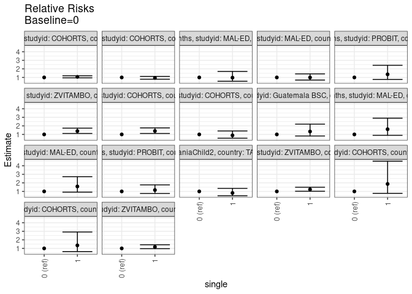

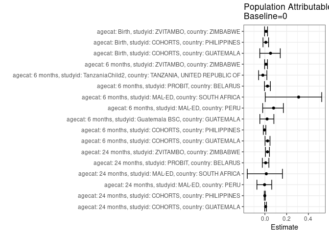

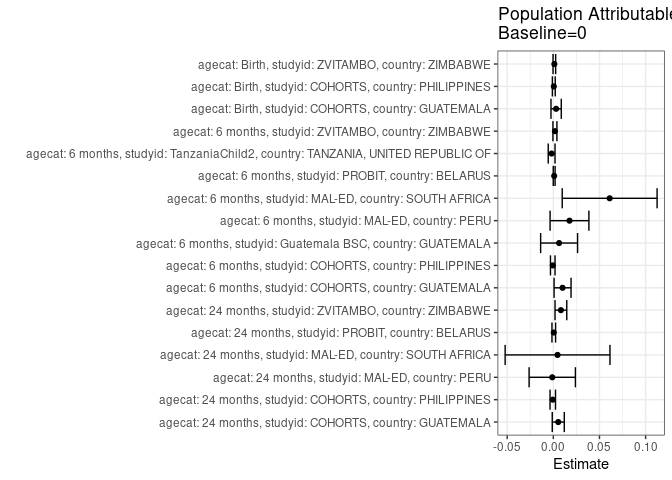

## Results Table

### Parameter: TSM

| agecat | studyid | country | intervention_level | baseline_level | estimate | ci_lower | ci_upper |
| --- | --- | --- | --- | --- | --- | --- | --- |
| Birth | COHORTS | GUATEMALA | 0 | NA | 0.0556328 | 0.0388678 | 0.0723978 |
| Birth | COHORTS | GUATEMALA | 1 | NA | 0.1041667 | 0.0176920 | 0.1906413 |
| Birth | COHORTS | PHILIPPINES | 0 | NA | 0.0599455 | 0.0513537 | 0.0685373 |
| Birth | COHORTS | PHILIPPINES | 1 | NA | 0.0810811 | 0.0199126 | 0.1422496 |
| Birth | ZVITAMBO | ZIMBABWE | 0 | NA | 0.1023156 | 0.0970903 | 0.1075410 |
| Birth | ZVITAMBO | ZIMBABWE | 1 | NA | 0.1200775 | 0.0978192 | 0.1423357 |
| 6 months | COHORTS | GUATEMALA | 0 | NA | 0.3976130 | 0.3642567 | 0.4309693 |
| 6 months | COHORTS | GUATEMALA | 1 | NA | 0.5569960 | 0.4366287 | 0.6773634 |
| 6 months | COHORTS | PHILIPPINES | 0 | NA | 0.2125055 | 0.1967638 | 0.2282471 |
| 6 months | COHORTS | PHILIPPINES | 1 | NA | 0.1888374 | 0.1036313 | 0.2740435 |
| 6 months | Guatemala BSC | GUATEMALA | 0 | NA | 0.3042123 | 0.2466651 | 0.3617594 |
| 6 months | Guatemala BSC | GUATEMALA | 1 | NA | 0.4078880 | 0.2207969 | 0.5949791 |
| 6 months | MAL-ED | PERU | 0 | NA | 0.2022625 | 0.1514109 | 0.2531141 |
| 6 months | MAL-ED | PERU | 1 | NA | 0.3252314 | 0.1509820 | 0.4994807 |
| 6 months | MAL-ED | SOUTH AFRICA | 0 | NA | 0.1358163 | 0.0740104 | 0.1976222 |
| 6 months | MAL-ED | SOUTH AFRICA | 1 | NA | 0.2145097 | 0.1505284 | 0.2784910 |
| 6 months | PROBIT | BELARUS | 0 | NA | 0.0384096 | 0.0281948 | 0.0486244 |
| 6 months | PROBIT | BELARUS | 1 | NA | 0.0445407 | 0.0272234 | 0.0618580 |
| 6 months | TanzaniaChild2 | TANZANIA, UNITED REPUBLIC OF | 0 | NA | 0.0987126 | 0.0850670 | 0.1123582 |
| 6 months | TanzaniaChild2 | TANZANIA, UNITED REPUBLIC OF | 1 | NA | 0.0805058 | 0.0412282 | 0.1197834 |
| 6 months | ZVITAMBO | ZIMBABWE | 0 | NA | 0.1611508 | 0.1531316 | 0.1691701 |
| 6 months | ZVITAMBO | ZIMBABWE | 1 | NA | 0.1987353 | 0.1620753 | 0.2353954 |
| 24 months | COHORTS | GUATEMALA | 0 | NA | 0.8094937 | 0.7841904 | 0.8347970 |
| 24 months | COHORTS | GUATEMALA | 1 | NA | 0.8638303 | 0.7695882 | 0.9580724 |
| 24 months | COHORTS | PHILIPPINES | 0 | NA | 0.6264249 | 0.6068024 | 0.6460473 |
| 24 months | COHORTS | PHILIPPINES | 1 | NA | 0.5900391 | 0.4868464 | 0.6932318 |
| 24 months | MAL-ED | PERU | 0 | NA | 0.3693182 | 0.2978389 | 0.4407975 |
| 24 months | MAL-ED | PERU | 1 | NA | 0.3600000 | 0.1713737 | 0.5486263 |
| 24 months | MAL-ED | SOUTH AFRICA | 0 | NA | 0.3483597 | 0.2651575 | 0.4315620 |
| 24 months | MAL-ED | SOUTH AFRICA | 1 | NA | 0.3457459 | 0.2547402 | 0.4367516 |
| 24 months | PROBIT | BELARUS | 0 | NA | 0.0676692 | 0.0405742 | 0.0947642 |
| 24 months | PROBIT | BELARUS | 1 | NA | 0.0922625 | 0.0518778 | 0.1326471 |
| 24 months | ZVITAMBO | ZIMBABWE | 0 | NA | 0.3381609 | 0.3145084 | 0.3618133 |
| 24 months | ZVITAMBO | ZIMBABWE | 1 | NA | 0.4696603 | 0.3707167 | 0.5686039 |

### Parameter: E(Y)

| agecat | studyid | country | intervention_level | baseline_level | estimate | ci_lower | ci_upper |
| --- | --- | --- | --- | --- | --- | --- | --- |
| Birth | COHORTS | GUATEMALA | NA | NA | 0.0586701 | 0.0420278 | 0.0753124 |
| Birth | COHORTS | PHILIPPINES | NA | NA | 0.0604651 | 0.0519489 | 0.0689813 |
| Birth | ZVITAMBO | ZIMBABWE | NA | NA | 0.1034233 | 0.0983457 | 0.1085009 |
| 6 months | COHORTS | GUATEMALA | NA | NA | 0.4076148 | 0.3753675 | 0.4398620 |
| 6 months | COHORTS | PHILIPPINES | NA | NA | 0.2118834 | 0.1963977 | 0.2273691 |
| 6 months | Guatemala BSC | GUATEMALA | NA | NA | 0.3104693 | 0.2558835 | 0.3650551 |
| 6 months | MAL-ED | PERU | NA | NA | 0.2197802 | 0.1705687 | 0.2689917 |
| 6 months | MAL-ED | SOUTH AFRICA | NA | NA | 0.1968504 | 0.1478551 | 0.2458457 |
| 6 months | PROBIT | BELARUS | NA | NA | 0.0393401 | 0.0293640 | 0.0493162 |
| 6 months | TanzaniaChild2 | TANZANIA, UNITED REPUBLIC OF | NA | NA | 0.0968703 | 0.0839461 | 0.1097946 |
| 6 months | ZVITAMBO | ZIMBABWE | NA | NA | 0.1628849 | 0.1550974 | 0.1706725 |
| 24 months | COHORTS | GUATEMALA | NA | NA | 0.8148515 | 0.7908851 | 0.8388178 |
| 24 months | COHORTS | PHILIPPINES | NA | NA | 0.6258278 | 0.6065280 | 0.6451276 |
| 24 months | MAL-ED | PERU | NA | NA | 0.3681592 | 0.3013164 | 0.4350020 |
| 24 months | MAL-ED | SOUTH AFRICA | NA | NA | 0.3529412 | 0.2921001 | 0.4137823 |
| 24 months | PROBIT | BELARUS | NA | NA | 0.0681537 | 0.0420376 | 0.0942697 |
| 24 months | ZVITAMBO | ZIMBABWE | NA | NA | 0.3463653 | 0.3233089 | 0.3694217 |

### Parameter: RR

| agecat | studyid | country | intervention_level | baseline_level | estimate | ci_lower | ci_upper |
| --- | --- | --- | --- | --- | --- | --- | --- |
| Birth | COHORTS | GUATEMALA | 0 | 0 | 1.0000000 | 1.0000000 | 1.000000 |
| Birth | COHORTS | GUATEMALA | 1 | 0 | 1.8723958 | 0.7741873 | 4.528447 |
| Birth | COHORTS | PHILIPPINES | 0 | 0 | 1.0000000 | 1.0000000 | 1.000000 |
| Birth | COHORTS | PHILIPPINES | 1 | 0 | 1.3525799 | 0.6275750 | 2.915145 |
| Birth | ZVITAMBO | ZIMBABWE | 0 | 0 | 1.0000000 | 1.0000000 | 1.000000 |
| Birth | ZVITAMBO | ZIMBABWE | 1 | 0 | 1.1735983 | 0.9683524 | 1.422347 |
| 6 months | COHORTS | GUATEMALA | 0 | 0 | 1.0000000 | 1.0000000 | 1.000000 |
| 6 months | COHORTS | GUATEMALA | 1 | 0 | 1.4008497 | 1.1127319 | 1.763569 |
| 6 months | COHORTS | PHILIPPINES | 0 | 0 | 1.0000000 | 1.0000000 | 1.000000 |
| 6 months | COHORTS | PHILIPPINES | 1 | 0 | 0.8886237 | 0.5627716 | 1.403148 |
| 6 months | Guatemala BSC | GUATEMALA | 0 | 0 | 1.0000000 | 1.0000000 | 1.000000 |
| 6 months | Guatemala BSC | GUATEMALA | 1 | 0 | 1.3408007 | 0.8152249 | 2.205215 |
| 6 months | MAL-ED | PERU | 0 | 0 | 1.0000000 | 1.0000000 | 1.000000 |
| 6 months | MAL-ED | PERU | 1 | 0 | 1.6079667 | 0.8917622 | 2.899379 |
| 6 months | MAL-ED | SOUTH AFRICA | 0 | 0 | 1.0000000 | 1.0000000 | 1.000000 |
| 6 months | MAL-ED | SOUTH AFRICA | 1 | 0 | 1.5794103 | 0.9167273 | 2.721133 |
| 6 months | PROBIT | BELARUS | 0 | 0 | 1.0000000 | 1.0000000 | 1.000000 |
| 6 months | PROBIT | BELARUS | 1 | 0 | 1.1596245 | 0.7617975 | 1.765205 |
| 6 months | TanzaniaChild2 | TANZANIA, UNITED REPUBLIC OF | 0 | 0 | 1.0000000 | 1.0000000 | 1.000000 |
| 6 months | TanzaniaChild2 | TANZANIA, UNITED REPUBLIC OF | 1 | 0 | 0.8155574 | 0.4913993 | 1.353551 |
| 6 months | ZVITAMBO | ZIMBABWE | 0 | 0 | 1.0000000 | 1.0000000 | 1.000000 |
| 6 months | ZVITAMBO | ZIMBABWE | 1 | 0 | 1.2332255 | 1.0191495 | 1.492269 |
| 24 months | COHORTS | GUATEMALA | 0 | 0 | 1.0000000 | 1.0000000 | 1.000000 |
| 24 months | COHORTS | GUATEMALA | 1 | 0 | 1.0671242 | 0.9525937 | 1.195425 |
| 24 months | COHORTS | PHILIPPINES | 0 | 0 | 1.0000000 | 1.0000000 | 1.000000 |
| 24 months | COHORTS | PHILIPPINES | 1 | 0 | 0.9419152 | 0.7890194 | 1.124439 |
| 24 months | MAL-ED | PERU | 0 | 0 | 1.0000000 | 1.0000000 | 1.000000 |
| 24 months | MAL-ED | PERU | 1 | 0 | 0.9747692 | 0.5575963 | 1.704056 |
| 24 months | MAL-ED | SOUTH AFRICA | 0 | 0 | 1.0000000 | 1.0000000 | 1.000000 |
| 24 months | MAL-ED | SOUTH AFRICA | 1 | 0 | 0.9924968 | 0.6958446 | 1.415617 |
| 24 months | PROBIT | BELARUS | 0 | 0 | 1.0000000 | 1.0000000 | 1.000000 |
| 24 months | PROBIT | BELARUS | 1 | 0 | 1.3634333 | 0.7672919 | 2.422742 |
| 24 months | ZVITAMBO | ZIMBABWE | 0 | 0 | 1.0000000 | 1.0000000 | 1.000000 |
| 24 months | ZVITAMBO | ZIMBABWE | 1 | 0 | 1.3888665 | 1.1129103 | 1.733249 |

### Parameter: PAR

| agecat | studyid | country | intervention_level | baseline_level | estimate | ci_lower | ci_upper |
| --- | --- | --- | --- | --- | --- | --- | --- |
| Birth | COHORTS | GUATEMALA | 0 | NA | 0.0030373 | -0.0025377 | 0.0086123 |
| Birth | COHORTS | PHILIPPINES | 0 | NA | 0.0005196 | -0.0010290 | 0.0020683 |
| Birth | ZVITAMBO | ZIMBABWE | 0 | NA | 0.0011077 | -0.0003140 | 0.0025294 |
| 6 months | COHORTS | GUATEMALA | 0 | NA | 0.0100018 | 0.0008071 | 0.0191965 |
| 6 months | COHORTS | PHILIPPINES | 0 | NA | -0.0006221 | -0.0030942 | 0.0018501 |
| 6 months | Guatemala BSC | GUATEMALA | 0 | NA | 0.0062570 | -0.0137504 | 0.0262645 |
| 6 months | MAL-ED | PERU | 0 | NA | 0.0175177 | -0.0035053 | 0.0385407 |
| 6 months | MAL-ED | SOUTH AFRICA | 0 | NA | 0.0610340 | 0.0096409 | 0.1124272 |
| 6 months | PROBIT | BELARUS | 0 | NA | 0.0009305 | -0.0000605 | 0.0019216 |
| 6 months | TanzaniaChild2 | TANZANIA, UNITED REPUBLIC OF | 0 | NA | -0.0018423 | -0.0055186 | 0.0018341 |
| 6 months | ZVITAMBO | ZIMBABWE | 0 | NA | 0.0017341 | -0.0004136 | 0.0038817 |
| 24 months | COHORTS | GUATEMALA | 0 | NA | 0.0053578 | -0.0011549 | 0.0118705 |
| 24 months | COHORTS | PHILIPPINES | 0 | NA | -0.0005971 | -0.0035496 | 0.0023555 |
| 24 months | MAL-ED | PERU | 0 | NA | -0.0011590 | -0.0262516 | 0.0239336 |
| 24 months | MAL-ED | SOUTH AFRICA | 0 | NA | 0.0045814 | -0.0522119 | 0.0613748 |
| 24 months | PROBIT | BELARUS | 0 | NA | 0.0004845 | -0.0014813 | 0.0024502 |
| 24 months | ZVITAMBO | ZIMBABWE | 0 | NA | 0.0082044 | 0.0018488 | 0.0145601 |

### Parameter: PAF

| agecat | studyid | country | intervention_level | baseline_level | estimate | ci_lower | ci_upper |
| --- | --- | --- | --- | --- | --- | --- | --- |
| Birth | COHORTS | GUATEMALA | 0 | NA | 0.0517694 | -0.0470659 | 0.1412754 |
| Birth | COHORTS | PHILIPPINES | 0 | NA | 0.0085936 | -0.0173296 | 0.0338562 |
| Birth | ZVITAMBO | ZIMBABWE | 0 | NA | 0.0107103 | -0.0031240 | 0.0243537 |
| 6 months | COHORTS | GUATEMALA | 0 | NA | 0.0245374 | 0.0016712 | 0.0468798 |
| 6 months | COHORTS | PHILIPPINES | 0 | NA | -0.0029358 | -0.0146682 | 0.0086609 |
| 6 months | Guatemala BSC | GUATEMALA | 0 | NA | 0.0201535 | -0.0464412 | 0.0825102 |
| 6 months | MAL-ED | PERU | 0 | NA | 0.0797056 | -0.0202823 | 0.1698947 |
| 6 months | MAL-ED | SOUTH AFRICA | 0 | NA | 0.3100530 | 0.0034913 | 0.5223053 |
| 6 months | PROBIT | BELARUS | 0 | NA | 0.0236531 | -0.0037289 | 0.0502880 |
| 6 months | TanzaniaChild2 | TANZANIA, UNITED REPUBLIC OF | 0 | NA | -0.0190177 | -0.0576159 | 0.0181718 |
| 6 months | ZVITAMBO | ZIMBABWE | 0 | NA | 0.0106461 | -0.0026225 | 0.0237391 |
| 24 months | COHORTS | GUATEMALA | 0 | NA | 0.0065752 | -0.0014666 | 0.0145523 |
| 24 months | COHORTS | PHILIPPINES | 0 | NA | -0.0009540 | -0.0056821 | 0.0037518 |
| 24 months | MAL-ED | PERU | 0 | NA | -0.0031480 | -0.0736742 | 0.0627455 |
| 24 months | MAL-ED | SOUTH AFRICA | 0 | NA | 0.0129807 | -0.1618103 | 0.1614749 |
| 24 months | PROBIT | BELARUS | 0 | NA | 0.0071082 | -0.0235747 | 0.0368714 |
| 24 months | ZVITAMBO | ZIMBABWE | 0 | NA | 0.0236872 | 0.0051639 | 0.0418657 |